# Resolução dos Exercícios da Aula 11

Introdução à Ciência de Dados - 2026/1  
Mestrado em Administração

Autor

Prof. Dr. Washington S. da Silva

Data de Publicação

28 de maio de 2026

## Resolução do Exercício 1

O método da transformação inversa parte da seguinte ideia: se $U$ é uma variável aleatória com distribuição Uniforme no intervalo $(0,1)$, então podemos gerar uma variável aleatória $X$ com função de distribuição acumulada $F$ fazendo

$$X = F^{-1}(U).$$

Portanto, precisamos encontrar a função inversa da função de distribuição acumulada da distribuição Logística.

A função de distribuição acumulada é

$$F(x) = \frac{1}{1 + e^{-(x - \mu)/\beta}}.$$

Fazendo:

$$u = F(x),$$

temos:

$$u = \frac{1}{1 + e^{-(x - \mu)/\beta}}.$$

Agora, vamos isolar $x$.

Primeiro, multiplicamos os dois lados por $1 + e^{-(x - \mu)/\beta}$:

$$u\left(1 + e^{-(x - \mu)/\beta}\right) = 1.$$

Distribuindo $u$, obtemos:

$$u + u e^{-(x - \mu)/\beta} = 1.$$

Subtraindo $u$ dos dois lados:

$$u e^{-(x - \mu)/\beta} = 1 - u.$$

Dividindo os dois lados por $u$:

$$e^{-(x - \mu)/\beta} = \frac{1 - u}{u}.$$

Aplicando o logaritmo natural nos dois lados:

$$-\frac{x - \mu}{\beta} = \log\left(\frac{1 - u}{u}\right).$$

Multiplicando os dois lados por $-\beta$:

$$x - \mu = -\beta \log\left(\frac{1 - u}{u}\right).$$

Somando $\mu$ aos dois lados:

$$x = \mu - \beta \log\left(\frac{1 - u}{u}\right).$$

Como

$$-\log\left(\frac{1 - u}{u}\right) = \log\left(\frac{u}{1 - u}\right),$$

podemos escrever:

$$x = \mu + \beta \log\left(\frac{u}{1 - u}\right).$$

Logo, a função inversa da função de distribuição acumulada da distribuição Logística é

$$F^{-1}(u) = \mu + \beta \log\left(\frac{u}{1 - u}\right), \qquad 0 < u < 1.$$

Portanto, se $U \sim \text{Uniforme}(0,1)$ então $X = \mu + \beta \log\left(\frac{U}{1 - U}\right)$ segue uma distribuição Logística com parâmetros $\mu$ e $\beta$, conforme o método da trasnformação inversa da função de distribuição acumulada.

### 2. Simulação em R

O código abaixo gera 10.000 observações de uma variável aleatória com distribuição Logística usando o método da transformação inversa.

```r
# fixa a semente
set.seed(42)

# simula U ~ Uniforme(0,1)
u <- runif(10000)

# define os parâmetros da distribuição Logística
mu <- 0
beta <- 1

# gera X ~ Logística(mu, beta)
x <- mu + beta * log(u / (1 - u))
```

Nesse exemplo, usamos $\mu = 0$ e $\beta = 1$. Portanto, as 10.000 observações simuladas seguem uma distribuição Logística padrão.

Conforme o exemplo visto em aula, vamos verificar visualmente se os dados simulados se aproximam de uma distribuição logística. Para isso, construiremos um histograma da amostra simulada e sobreporemos a densidade teórica da distribuição logística, calculada em R pela função `dlogis`.

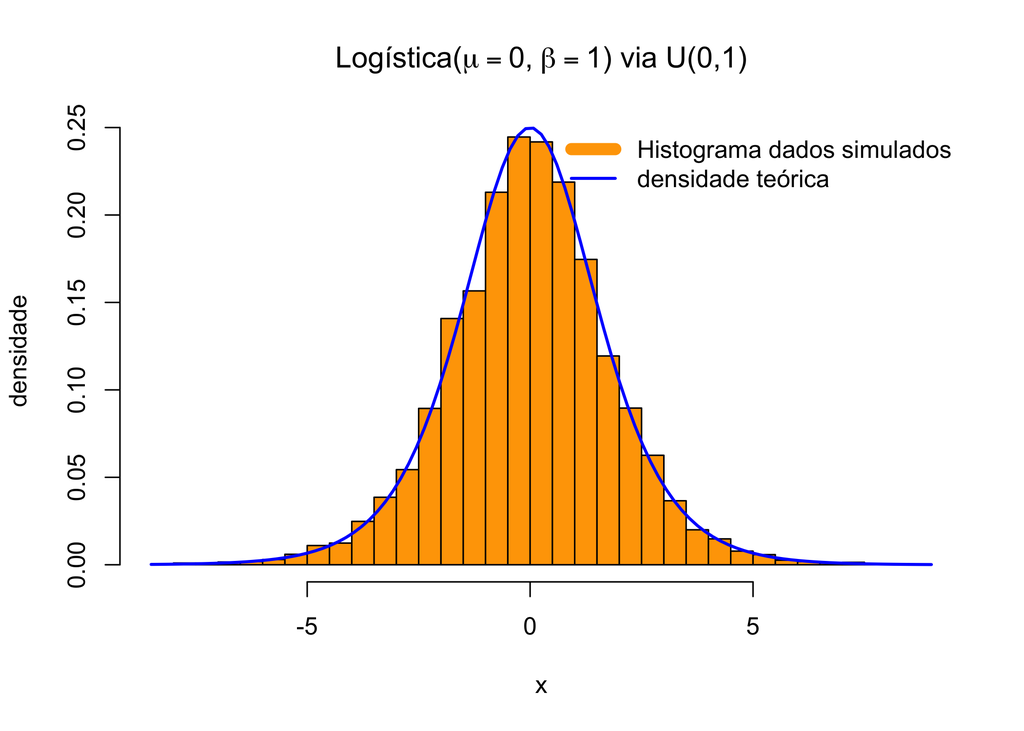

```r
# Histograma da amostra simulada ------------------------
hist(x,
      # número de classes do histograma
     breaks      = 30,
     # cor das barras
     col         = "orange",
     # escala em densidade (área total = 1)
     probability = TRUE,
     main = expression("Logística(" * mu == 0 * "," ~ beta == 1 * ") via U(0,1)"),
     xlab = "x",
     ylab = "densidade")


# Densidade teórica sobreposta --------------------------
curve(dlogis(x, location = mu, scale = beta),
      # adiciona a curva ao gráfico existente
      add = TRUE,
      col = "blue", lwd = 2)


# Legenda -----------------------------------------------
legend("topright",
       legend = c("Histograma dados simulados", "densidade teórica"),
       col    = c("orange", "blue"),
       lwd    = c(8, 2),
       lty    = 1,
       bty    = "n")
```

## Resolução do Exercício 2

Vamos simular o Índice de Liquidez Rápida (ILR) sob incerteza. O índice é definido por:

$$\text{ILR} =
\frac{\text{Ativo Circulante} - \text{Estoques}}
{\text{Passivo Circulante}}.$$

Como os valores de Ativo Circulante, Estoques e Passivo Circulante são incertos, vamos modelar cada uma dessas variáveis por meio de uma distribuição triangular. Essa distribuição é adequada quando dispomos de três informações: um valor mínimo, um valor máximo e um valor mais provável.

### 1. Simulação de 20.000 cenários

O código abaixo usa a função `rtri()` do pacote **EnvStats** para simular valores de distribuições triangulares.

```r
# carrega o pacote necessário
library(EnvStats)

# fixa a semente
set.seed(2024)

# número de simulações
n_sim <- 20000

# simula os componentes do ILR, em milhares de R$
ativo_circ <- rtri(n_sim, 800, 1200, 950)   # Ativo Circulante
estoques <- rtri(n_sim, 200, 400, 280)      # Estoques
passivo_circ <- rtri(n_sim, 600, 900, 720)  # Passivo Circulante

# calcula o ILR simulado em cada cenário
ilr_sim <- (ativo_circ - estoques) / passivo_circ
```

### 2. Probabilidade de ILR menor que 1

O evento $\text{ILR} < 1$ representa uma situação em que a empresa não conseguiria cobrir o Passivo Circulante usando apenas o Ativo Circulante líquido de estoques.

```r
# probabilidade estimada de ILR < 1
prob_ilr_menor_1 <- mean(ilr_sim < 1)

# probabilidade em porcentagem
prob_ilr_menor_1 * 100
```

```
[1] 67.405
```

A probabilidade simulada de $\text{ILR} < 1$ é de aproximadamente 67.4%.

Esse resultado indica que, **sob as hipóteses adotadas** na simulação, há uma **probabilidade elevada** de a empresa apresentar ILR inferior a 1. Em termos financeiros, isso sugere que, em muitos cenários, a empresa não teria ativos circulantes líquidos de estoques suficientes para cobrir suas obrigações de curto prazo.

Essa conclusão depende diretamente das hipóteses do exercício. A simulação não afirma que a empresa necessariamente enfrentará dificuldades de liquidez, mas indica que o risco de o ILR ficar abaixo do nível de referência é relevante.

### 3. Comparação com o modelo determinístico

No modelo determinístico, usamos os valores mais prováveis informados pelos especialistas:

$$\text{ILR}_{\text{det}} =
\frac{950 - 280}{720}.$$

```r
# ILR determinístico, usando os valores mais prováveis
ilr_det <- (950 - 280) / 720

# média e desvio-padrão do ILR simulado
ilr_medio <- mean(ilr_sim)
ilr_desvio <- sd(ilr_sim)

# comparação dos resultados
ilr_det
```

```
[1] 0.9305556
```

```r
ilr_medio
```

```
[1] 0.9380641
```

```r
ilr_desvio
```

```
[1] 0.1485529
```

O ILR determinístico é igual a 0.931, enquanto o ILR médio simulado é igual a 0.938. Esses valores podem ser próximos, mas eles não representam exatamente a mesma coisa. O ILR determinístico usa apenas os valores mais prováveis de Ativo Circulante, Estoques e Passivo Circulante. Já o ILR médio simulado considera todos os cenários gerados a partir das distribuições triangulares.

A simulação também permite observar a variabilidade do ILR. O desvio-padrão da distribuição dos índices simulados é igual a 0.149, o que mostra que a variabilidade do índice em torno de sua média é relativamente alta.

Portanto, a principal contribuição da simulação não é apenas calcular um valor médio, mas representar a incerteza em torno do indicador e estimar a probabilidade de ocorrência de situações consideradas desfavoráveis.

### 4. Visualização da distribuição simulada

O histograma abaixo mostra a distribuição dos valores simulados do ILR. A linha vermelha tracejada indica o valor crítico $\text{ILR} = 1$, e a linha azul indica o ILR médio simulado.

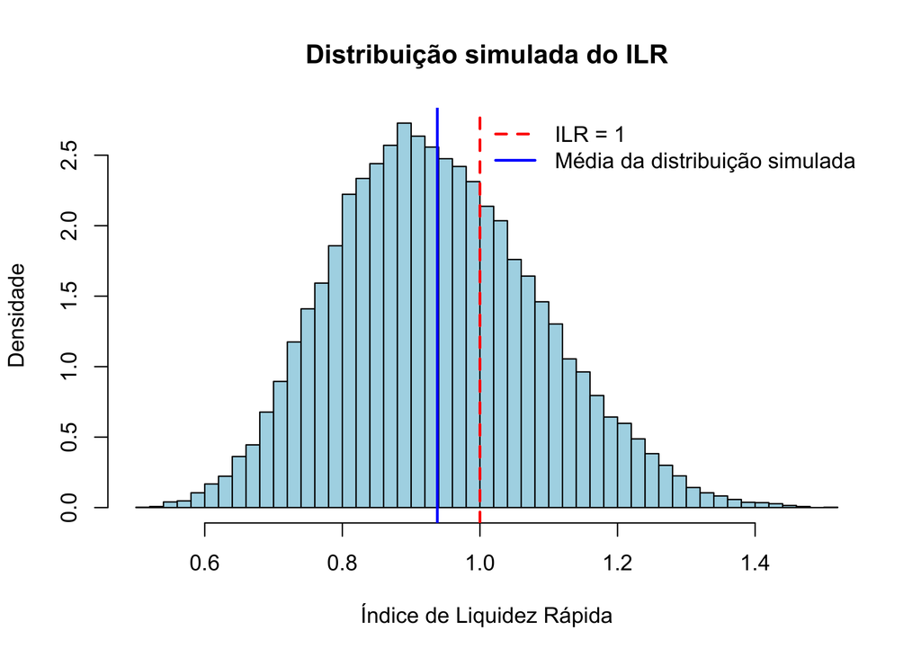

```r
# histograma do ILR simulado
hist(ilr_sim,
     breaks      = 50,
     col         = "lightblue",
     probability = TRUE,
     main        = "Distribuição simulada do ILR",
     xlab        = "Índice de Liquidez Rápida",
     ylab        = "Densidade")

# linha de referência: ILR = 1
abline(v = 1,
       col = "red",
       lwd = 2,
       lty = 2)

# linha da média da distribuição simulada
abline(v = ilr_medio,
       col = "blue",
       lwd = 2)

# legenda
legend("topright",
       legend = c("ILR = 1", "Média da distribuição simulada"),
       col    = c("red", "blue"),
       lwd    = 2,
       lty    = c(2, 1),
       bty    = "n")
```

### 5. Recomendação

Como a probabilidade estimada de $\text{ILR} < 1$ é de 67.4%, ela é maior que o limite de 40% definido no enunciado. Portanto, recomenda-se a adoção de medidas preventivas de gestão de liquidez.

Entre as possíveis ações, destacam-se:

- manter uma reserva mínima de caixa;
- avaliar a contratação preventiva de linhas de crédito de curto prazo;
- acompanhar o ILR periodicamente;
- revisar a política de estoques;
- reduzir o prazo médio de recebimento de clientes, quando possível;
- negociar prazos mais longos com fornecedores, quando possível.

Essas medidas não significam que a empresa esteja necessariamente em crise. O resultado da simulação indica que, **dadas as hipóteses adotadas**, existe risco relevante de o ILR ficar abaixo de 1. Assim, a recomendação mais prudente é monitorar o indicador e adotar medidas preventivas para reduzir a exposição da empresa a dificuldades de liquidez no curto prazo.